# Introduction to single-cell RNA-seq analysis

Cluster marker genes

# 1 Introduction

In order to aid the interpretation of the clustering results that we covered in the previous section, it is helpful to identify genes that contribute to the separation of cells into those clusters.

The main approach to achieve this, is to identify genes that are differently expressed between clusters. These may be, for example, exclusively expressed in a single cluster or perhaps differentiate between a few different clusters. There are different methods to identify expression differences between clusters: using mean expression level, or the ranking of the gene by its expression, or the proportions of cells that express the gene.

Our main objective in this section is to cover some of the methods that can be used to achieve this goal, and obtain a summary table of results. As always, the [OSCA chapter on marker detection](https://bioconductor.org/books/release/OSCA.basic/marker-detection.html) contains additional detail and advice.

# 2 Load data

```r
library(scater)
library(scran)
library(pheatmap)
library(tidyverse)
```

We will use the data set generated in the clustering session. This contains 7 samples from the Caron data set. For the purposes of these materials, in the interests of time, each sample has been downsampled to only contain 500 cells.

```r
sce <- readRDS("R_objects/Caron_clustered.500.rds")
```

Note that we have also replaced the gene names (rownames) of our objects to use common gene names instead of Ensembl IDs. This was done using the `uniquifyFeatureNames()` function makes this safely, avoiding duplicate gene names.

```r
rownames(sce)[11:20]
```

```
##  [1] "ENSG00000230699" "ENSG00000241180" "SAMD11"          "NOC2L"
##  [5] "KLHL17"          "PLEKHN1"         "ENSG00000272512" "HES4"
##  [9] "ISG15"           "ENSG00000224969"
```

For this demonstration we will investigate the clustering generated using the Leiden clustering algorithm with *k* set to 25. The results of this clustering have been added to a column in the `colData` called **“label”** using the `colLabels` accessor. The advantage of this is that should we later decide to use a different clustering, we can simply change the contents of this column and there would be no need to modify any subsequent code.

Double check that the “label” column contains the clustering that we are interested in:

```r
all(sce$k.25_cluster.fun.leiden==sce$label)
```

```
## [1] TRUE
```

To remind ourselves, we can visualise the clusters on a UMAP:

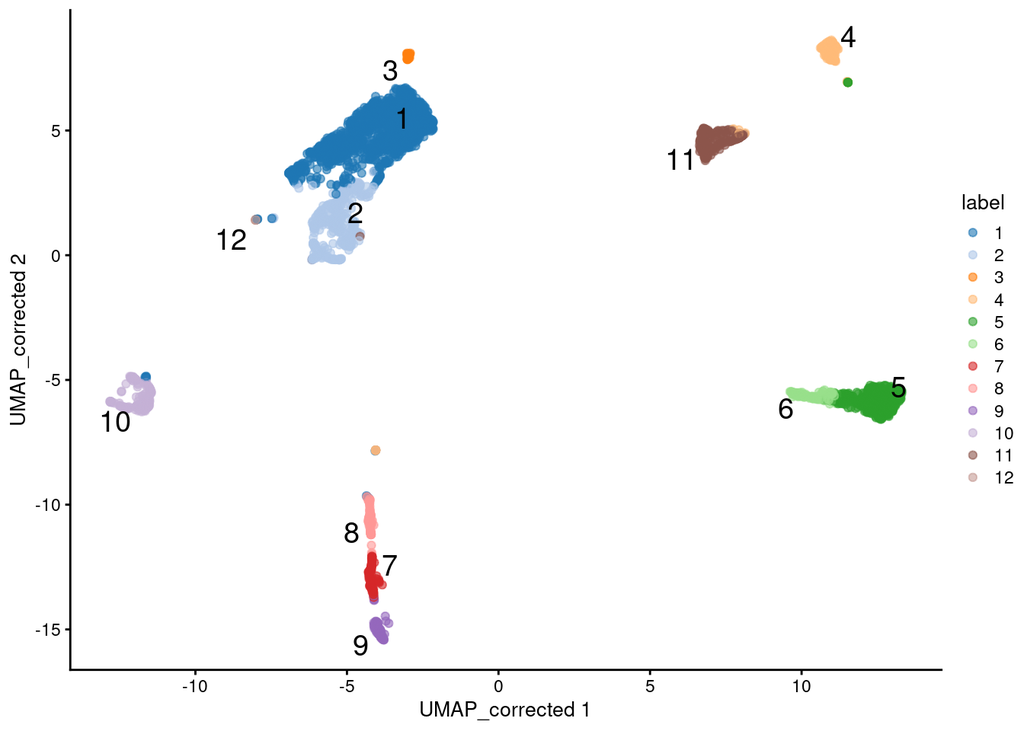

```r
plotReducedDim(sce,
               dimred = "UMAP_corrected",
               colour_by = "label",
               text_by = "label")
```

Our objective is to identify genes that distinguish between these clusters. For example genes such as the “CST3” gene, which is a known monocyte marker:

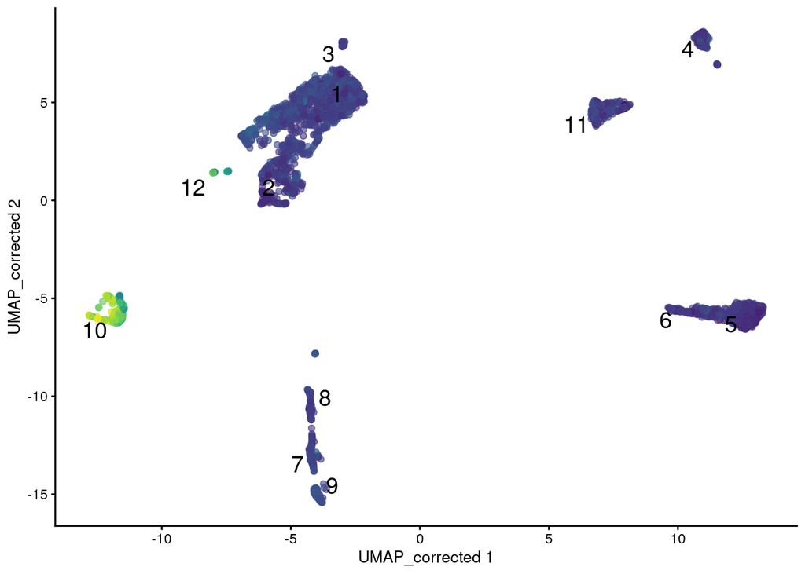

```r
plotReducedDim(sce,
               dimred = "UMAP_corrected",
               colour_by = "CST3",
               text_by = "label",
               by_exprs_values = "reconstructed",
               add_legend = FALSE)
```

# 3 Identifying cluster marker genes

Although we have defined our clusters based on the batch-corrected expression values, these should **not** be used for for gene-based analyses like marker gene detection. Instead, we should **use the uncorrected (normalised) expression values for differential expression between clusters**. This is because data integration algorithms bring cells together based on their overall gene expression, but for each gene individually the data transformation may introduce artificial agreement between batches, which is not ideal for gene-level differential analysis. Furthermore, the severity of these biases id dependent on the parameters used for data integration (such as the number of nearest neighbours in the `fastMNN()` method).

Valid assays to use in gene based differential analysis tests are the normalised counts obtained from the deconvolution method (using `scuttle::computePooledFactors()` + `scuttle::logNormCounts()`) or from the variance stabilising transformation method (using `sctransform::vst()`). In our SCE object, we have the normalised counts in the “logcounts” assay, which we can access with `assay(sce, "logcounts")` (or using the shortcut `logcounts(sce)`).

## 3.1 Pairwise Cluster Comparisons

The basic approach for marker gene identification across clusters is to perform statistical tests for each gene between every pair of clusters. The `scoreMarkers` function can do this for us, while accounting for known factors (aka “blocking factors” or “blocks”), such as sample batch.

The function outputs a *list* of `DataFrames`, one for each cluster compared to all others. However, note that the blocking assumes that each pair of clusters is present in at least one of the blocks. If there are two clusters which are not both present in at least one block (in our cases Samples), then that pairwise comparison will by necessity be omitted.

By default the `scoreMarkers` function will use the log normalised counts as stored in the “logcounts” assay slot of the single cell object.

```r
markers <- scoreMarkers(sce,
                        groups = sce$label,
                        block = sce$SampleName)
```

The returned object is a list of the same length as the number of clusters. We can access the results of a particular cluster thus:

```r
c10_markers <- as.data.frame(markers[["10"]])
head(c10_markers)
```

```
##                  self.average other.average self.detected other.detected
## MIR1302-2HG     -0.0001085355  0.0005858623  0.0000000000   3.432104e-04
## ENSG00000238009 -0.0006415454  0.0006144301  0.0007996515   1.814199e-03
## ENSG00000239945  0.0000000000  0.0000000000  0.0000000000   3.311745e-18
## ENSG00000241860  0.0146328719  0.0035313453  0.0127036973   2.165388e-03
## LINC01409        0.0143823227  0.0590411706  0.0080830488   3.468521e-02
## LINC00115        0.0006428644  0.0042533539  0.0053128929   5.607109e-03
##                 mean.logFC.cohen min.logFC.cohen median.logFC.cohen
## MIR1302-2HG         -0.006580174     -0.07238191        0.000000000
## ENSG00000238009     -0.017591283     -0.09310718        0.000000000
## ENSG00000239945      0.000000000      0.00000000        0.000000000
## ENSG00000241860      0.141411918      0.06093559        0.149321693
## LINC01409           -0.143168150     -0.42779501       -0.131631772
## LINC00115            0.013097401     -0.12320130        0.009314297
##                 max.logFC.cohen rank.logFC.cohen  mean.AUC   min.AUC median.AUC
## MIR1302-2HG           0.0000000             7524 0.4998119 0.4979311  0.5000000
## ENSG00000238009       0.0000000             8439 0.4988630 0.4922411  0.5000000
## ENSG00000239945       0.0000000             7524 0.5000000 0.5000000  0.5000000
## ENSG00000241860       0.1995937             2822 0.5074604 0.5038890  0.5080630
## LINC01409             0.1390217             8790 0.4823370 0.4350181  0.4884527
## LINC00115             0.1888446             8123 0.5007662 0.4904221  0.5016101
##                   max.AUC rank.AUC mean.logFC.detected min.logFC.detected
## MIR1302-2HG     0.5000000     5268       -3.703415e-02      -4.073757e-01
## ENSG00000238009 0.5000000     7065       -6.317926e-02      -2.793215e-01
## ENSG00000239945 0.5000000     5268       -3.952634e-17      -2.528729e-16
## ENSG00000241860 0.5105900     2431        5.706501e-01       1.368573e-01
## LINC01409       0.5075643     8600       -6.884798e-01      -1.870109e+00
## LINC00115       0.5093492     6870        5.199862e-02      -6.760815e-01
##                 median.logFC.detected max.logFC.detected rank.logFC.detected
## MIR1302-2HG              0.000000e+00       3.851448e-17                4739
## ENSG00000238009         -3.611062e-17       7.269500e-18                7010
## ENSG00000239945          0.000000e+00       3.851448e-17                4739
## ENSG00000241860          4.818850e-01       1.015435e+00                 971
## LINC01409               -6.314390e-01       1.032376e-01                8701
## LINC00115                5.993567e-02       9.536183e-01                6470
```

- **self.average** - the mean log-expression in the cluster of interest
- **other.average** - the grand mean across all other clusters
- **self.detected** - the proportion of cells with detected expression in the cluster of interest
- **other.detected** - the mean detected proportion across all other clusters.

The remaining columns contain summaries of three scores from the pairwise comparisons. The three scores are:

- **logFC.cohen** - “Cohen’s *d*” - this is the log fold change of mean gene expression that has been standardized by scaling by the average of the standard deviation across the groups. This can be interpreted in a similar way to log fold change in that a positive value indicates upregulation in the cluster of interest.
- **AUC** - “Area Under the Curve” - this quantifies the ability to distinguish between two gene expression distributions. It can be interpreted as the likelihood that any random cell in the cluster of interest will have a higher expression of the gene than any random cell in the other cluster. It ranges from 0 to 1, where 1 can be interpreted as upregulation, 0 downregulation, and 0.5 as no difference.
- **logFC.detected** - this is the log fold change in the proportion of cells in which the gene is detected in the cluster of interest versus the proportion of cells in which the gene is detected in the other cluster. Positive values indicate that the gene is detected in more cells in the cluster of interest than the other cluster. Note, this takes no account of the magnitude of the gene expression, instead this metric helps to identify presence/absence differences in gene expression between clusters.

More detail on the differences between these effect size scores can be found in the [“Advanced” Marker detection chapter of the OSCA book](http://bioconductor.org/books/3.15/OSCA.advanced/marker-detection-redux.html#properties-of-each-effect-size).

Whilst all the pairwise scores can be retrieved by adding the argument `full.stats=TRUE` to `scoreMarkers()`, by default this function returns 5 summary statistics for each score:

- **mean.X** - this is the mean of the score across all pairwise comparisons. It gives the relative expression of the gene versus the average of the other clusters.
- **min.X** - this is the minimum score obtained across all pairwise comparisons. This is the most stringent summary statistic for detecting upregulated genes, if the score is high, then the gene is upregulated in the cluster of interest relative to *all* other clusters. Conversely, if the minimum is low, then the gene is downregulated relative to *at least one* other cluster.
- **median.X** - this is the median of the score across all pairwise comparisons. It is more robust to outliers than the mean. Whilst this is beneficial in avoiding the situation where the effect size is very large in only a small number of comparisons, it may conversely be detrimental to marker gene selection if there are small number of clusters with very similar effect sizes, as these will be effectively ignored.
- **max.X** - this is the maximum score obtained across all pairwise comparisons. This is the least stringent summary statistic for detecting upregulated genes as a high score only indicates that the gene is upregulated in the cluster of interest relative to *at least one* other clusters. Conversely, if the maximum is low, then the gene is downregulated relative to *all* other clusters.
- **rank.X** - This is the minimum ranking (“min-rank”) of that gene by that score across all clusters. For each pairwise comparison the genes are ranked according to the score, this summary provides the lowest rank for that gene across all comparisons. Essentially, a gene with a low “min-rank” will be one of the best genes according to that score in at least one comparison.

The choice of the summary used for ranking will effect the stringency of the selection. See the [the OSCA books “Basic” chapter on Marker gene detection](http://bioconductor.org/books/3.15/OSCA.basic/marker-detection.html#summarizing-pairwise-effects) for further discussion of these different summaries. In general the mean and median make reasonable defaults for most applications. In practice, the minimum and maximum are most helpful for diagnosing discrepancies between the mean and median, rather than being used directly for ranking.

Selecting genes based on a given min-rank, say *5*, is useful as it will generate a list of genes that is the union of genes with a rank of 5 or less for any pairwise comparison. This will ensure we get at least 5 genes that distinguish the cluster of interest from all other clusters.

For example using the min-rank for Cohen’s *d* on cluster 10 yields 20 marker genes:

```r
c10_markers %>%
  select(contains("cohen")) %>%
  filter(rank.logFC.cohen <= 5) %>%
  arrange(rank.logFC.cohen)
```

```
##                 mean.logFC.cohen min.logFC.cohen median.logFC.cohen
## S100A6                 3.9980968       1.6451192          3.6333222
## MNDA                   2.8846906       2.4886487          2.8608354
## FCER1G                 3.5312969       0.5090234          3.4586321
## LYZ                    4.6547138       2.1232942          4.8565839
## TYROBP                 4.2129157       2.3217781          4.5349668
## CST3                   3.7611775       1.0118157          4.2018285
## TMSB4X                 2.9711679       0.8917935          2.6002233
## S100A4                 3.9758078       1.8470682          4.3663636
## LYN                    1.6353181      -0.2301748          1.9335304
## SRGN                   3.5078590       1.3596723          3.4614617
## COTL1                  3.2156435       1.4159094          3.2713360
## FTL                    2.7266481      -0.3085039          2.7633264
## TMSB10                 2.0387403       0.7580912          1.7825497
## GAPDH                  2.2130250       0.4319294          2.1553465
## ENSG00000257764        2.5969689       1.6831756          2.5855829
## LGALS1                 3.8793702       1.8834508          4.0252487
## LST1                   3.2858400       2.1604681          3.3118139
## AIF1                   2.9115158       1.9807963          3.0578504
## RPS3A                  0.8666418      -0.8608249          0.1660708
## SNX10                  1.8079267       0.3188842          1.4977122
##                 max.logFC.cohen rank.logFC.cohen
## S100A6                 7.930903                1
## MNDA                   3.469624                1
## FCER1G                 7.030043                1
## LYZ                    6.254798                1
## TYROBP                 6.053634                1
## CST3                   5.005112                1
## TMSB4X                 6.659286                1
## S100A4                 6.661203                2
## LYN                    3.331864                2
## SRGN                   5.519514                2
## COTL1                  6.408767                2
## FTL                    6.913409                2
## TMSB10                 4.735887                3
## GAPDH                  4.617009                3
## ENSG00000257764        3.497302                3
## LGALS1                 4.802365                3
## LST1                   4.431111                4
## AIF1                   3.569574                4
## RPS3A                  6.575678                5
## SNX10                  4.861811                5
```

As we suspected, cluster 10 is likely to contain monocytes, based on the expression of *CST3* and *TYROBP*, for example.

We can visualise the expression of some of the other top-ranked genes:

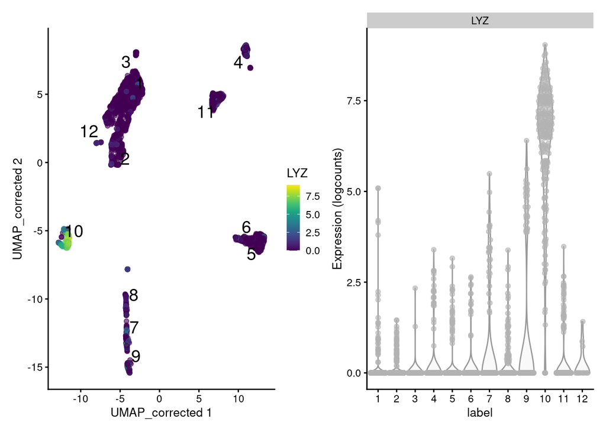

```r
p1 <- plotReducedDim(sce,
                     dimred = "UMAP_corrected",
                     colour_by = "LYZ",
                     text_by = "label")

p2 <- plotExpression(sce, features = "LYZ", x = "label")

p1 + p2
```

Based on the expression of *CD3D*, which is a known marker for T cells, it seems likely that cells in clusters 5 and 6 are T-cells.

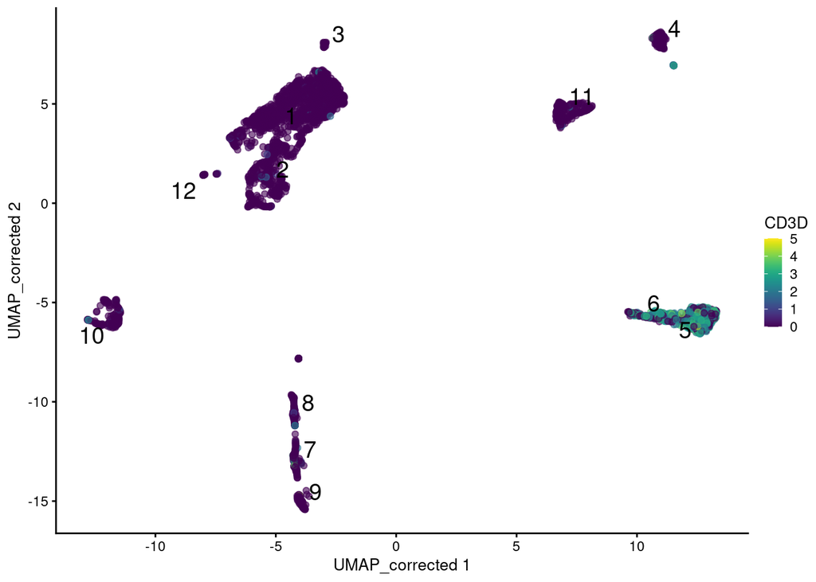

```r
plotReducedDim(sce,
               dimred = "UMAP_corrected",
               colour_by = "CD3D",
               text_by = "label")
```

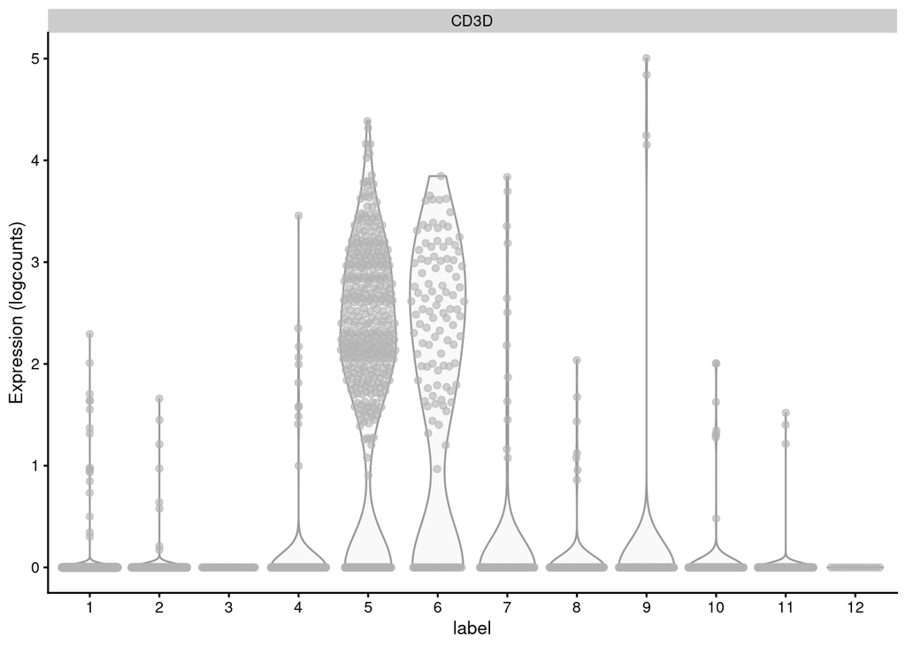

```r
plotExpression(sce,
               features = "CD3D",
               x = "label")
```

We would like to confirm this by identifying other genes that differentiate these two clusters from the rest of the cells.

1. Extract results for cluster 5 and convert it to data.frame
2. Filter the data.frame using your choice of ranking statistic - `rank.logFC.detected` or `rank.logFC.cohen` or a combination of both!
3. Visualise the expression of genes that seem interesting from your filters

**Hint**

Fix the code below (where the word “FIXME” appears) to extract the data frame with metrics for this cluster (from our `markers` object), filter it and then plot the expression of a few of the genes.

```r
# extract results from cluster 4 and convert to data.frame
c5_markers <- FIXME

# filter the data.frame using your choice of ranking statistic
# `rank.logFC.detected` or `rank.logFC.cohen`
# or a combination of both!
c5_markers %>%
  filter(FIXME)

# visualise the expression of genes that seem interesting from your filters
plotExpression(sce,
               features = FIXME,
               x = "label")
```

**Answer**

Start by extracting the marker results for cluster 5 from our list:

```r
c5_markers <- as.data.frame(markers[["5"]])
```

In our case, we chose to then filter our table with two criteria to find genes that:

AND

- have a Cohen’s *d* in the top 10 (i.e. the average expression difference should be high, relative to the gene’s variance)

```r
lenHit <- c5_markers %>%
  filter(rank.logFC.detected <= 2 & rank.logFC.cohen <= 10) %>%
  nrow()
```

```r
top_genes <- c5_markers %>%
  filter(rank.logFC.detected <= 3 & rank.logFC.cohen <= 10)
top_genes
```

```
##        self.average other.average self.detected other.detected mean.logFC.cohen
## LEF1       1.953398     0.7129454     0.8646253     0.36378197        1.2740781
## BACH2      1.057763     0.2957412     0.5855458     0.32817785        0.8641514
## CD3E       1.602520     0.2242160     0.4799064     0.04797738        1.5593600
## CD3D       1.792324     0.1556523     0.4099144     0.03288734        1.9586249
## PRKCH      1.667023     0.3410926     0.7535383     0.23039125        1.4343425
## BCL11B     1.787629     0.1791308     0.9170275     0.17868512        1.9255985
## IL32       1.851906     0.3739783     0.6028484     0.07852677        1.7594579
##        min.logFC.cohen median.logFC.cohen max.logFC.cohen rank.logFC.cohen
## LEF1        0.30870520           1.499288        1.918810                3
## BACH2      -2.16459592           1.177666        2.838441                5
## CD3E       -0.06064829           1.695426        2.021056                7
## CD3D        0.08663408           2.213165        2.557380                1
## PRKCH      -0.35849274           1.725187        2.290630                4
## BCL11B      0.52733516           2.028536        2.642743                2
## IL32       -0.69864630           1.911143        2.824283                6
##         mean.AUC    min.AUC median.AUC   max.AUC rank.AUC mean.logFC.detected
## LEF1   0.7595202 0.55602303  0.8206517 0.8564944       13            2.021606
## BACH2  0.6390374 0.06097018  0.7601988 0.9184906       13            1.091456
## CD3E   0.7961033 0.48139833  0.8206927 0.8631532       19            3.149840
## CD3D   0.8334423 0.51754330  0.8657850 0.9018868        6            2.995497
## PRKCH  0.7655168 0.41270045  0.8230271 0.8777358       20            1.995629
## BCL11B 0.8342915 0.64198204  0.8544745 0.9086792        5            3.100349
## IL32   0.7844467 0.29377806  0.8086737 0.9123118       28            2.875264
##        min.logFC.detected median.logFC.detected max.logFC.detected
## LEF1          -0.07487046              1.880776           4.464636
## BACH2         -0.33638827              1.105615           2.382381
## CD3E          -0.01124360              3.514154           4.819173
## CD3D           0.10497027              3.152769           4.993183
## PRKCH         -0.24091626              2.350629           3.882522
## BCL11B         0.39375791              3.183535           4.647754
## IL32          -0.37806735              2.960978           4.951184
##        rank.logFC.detected
## LEF1                     3
## BACH2                    1
## CD3E                     2
## CD3D                     1
## PRKCH                    2
## BCL11B                   1
## IL32                     1
```

Finally, we visualize the expression of these genes:

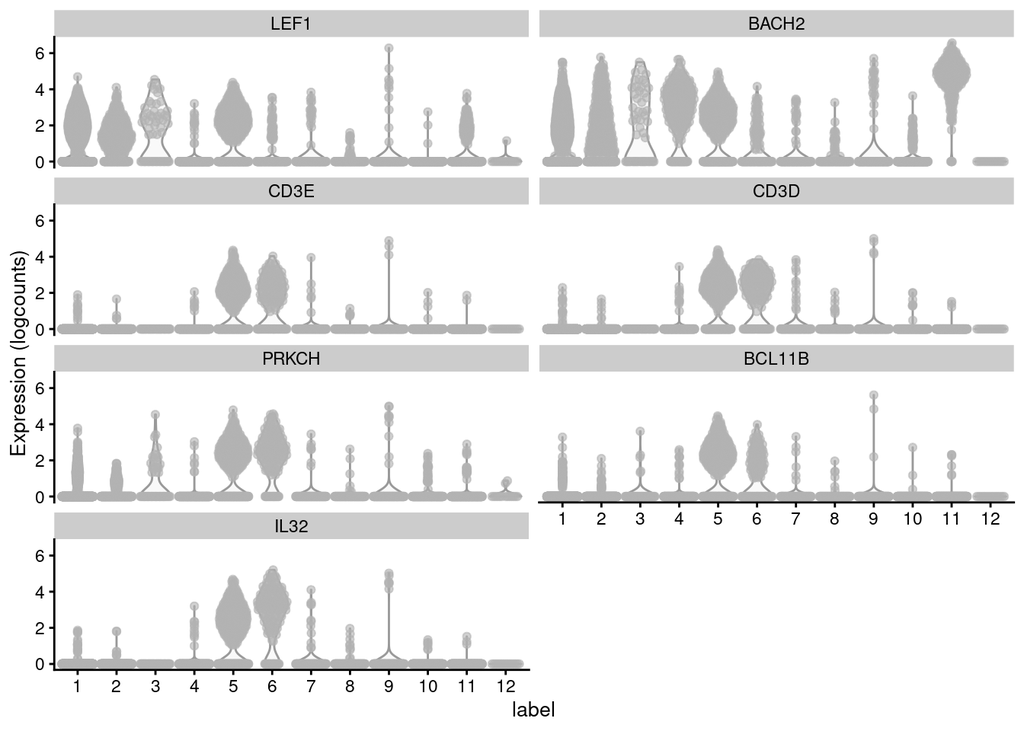

```r
plotExpression(sce,
               features = rownames(top_genes),
               x = "label")
```

## 3.2 Heatmap of marker genes

We have already seen how we can use the `plotExpression()` function to visualise the distribution of expression in our data between clusters. We have also seen how to use `plotReducedDim()` to visualise a gene’s expression on the projected reduced dimensionality space.

Another useful type of visualisation is to use **heatmaps** to show the expression of these genes of interest. We will demonstrate this using the top marker genes for cluster 10.

```r
c10_top_genes <- c10_markers %>%
  filter(rank.logFC.cohen <= 5)
```

We can make generate a heatmap showing the expression in individual cells using the function `plotHeatmap()`. We will arrange the columns (cells) so that cells from the same cluster and cells from the same samplegroup are grouped together.

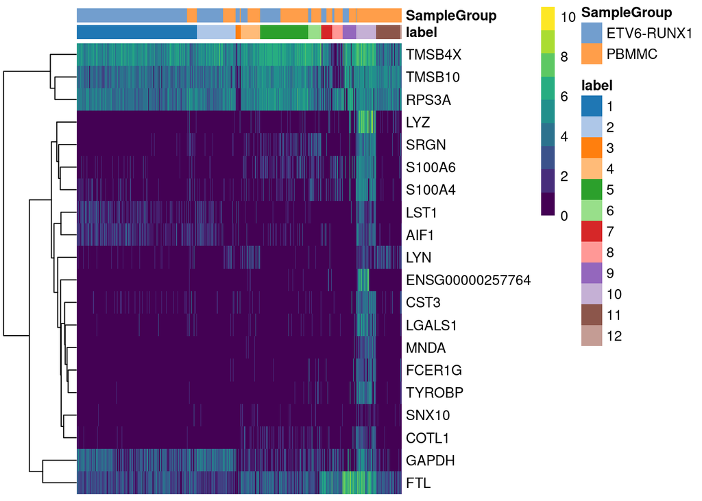

```r
plotHeatmap(sce,
            features = rownames(c10_top_genes),
            order_columns_by = c("label", "SampleGroup"))
```

Alternatively, we can summarise the expression across sample goups and generate a heatmap showing the average expression across cells within each group using the function `plotGroupedHeatmap()`.

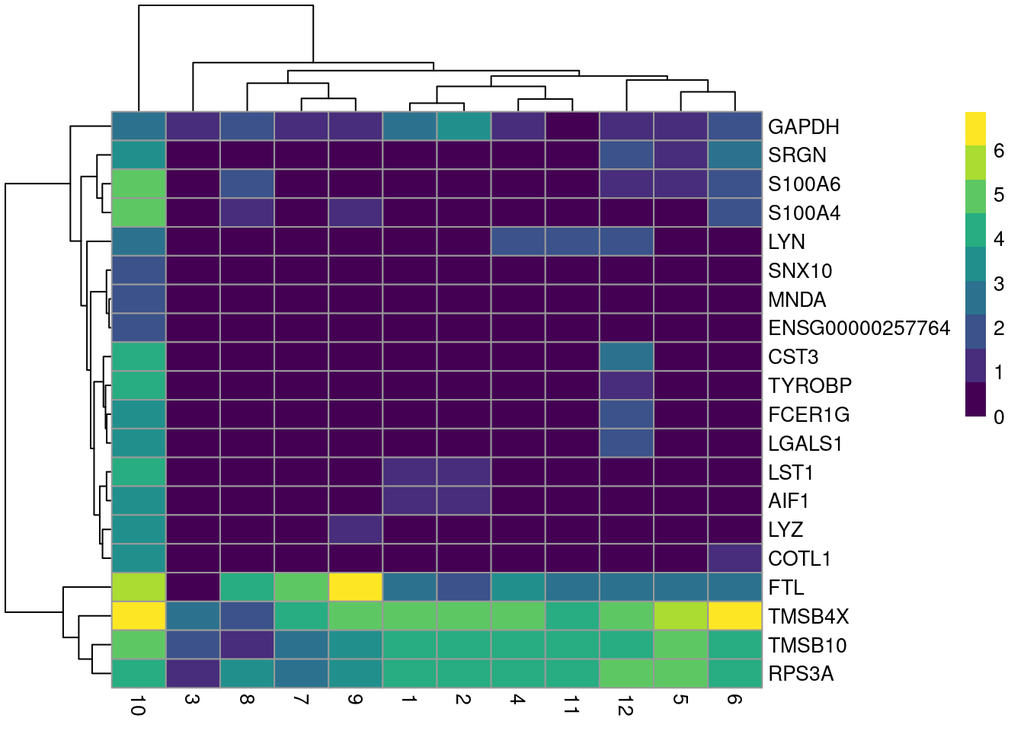

```r
plotGroupedHeatmap(sce,
                   features = rownames(c10_top_genes),
                   group = "label",
                   block = "SampleGroup")
```

In both cases, the colour scale of expression is showing the logcounts in their original scale. However, for this kind of visualisation, it may sometimes be useful to *scale* the data (aka Z-score), which brings all the genes to the same relative scale.

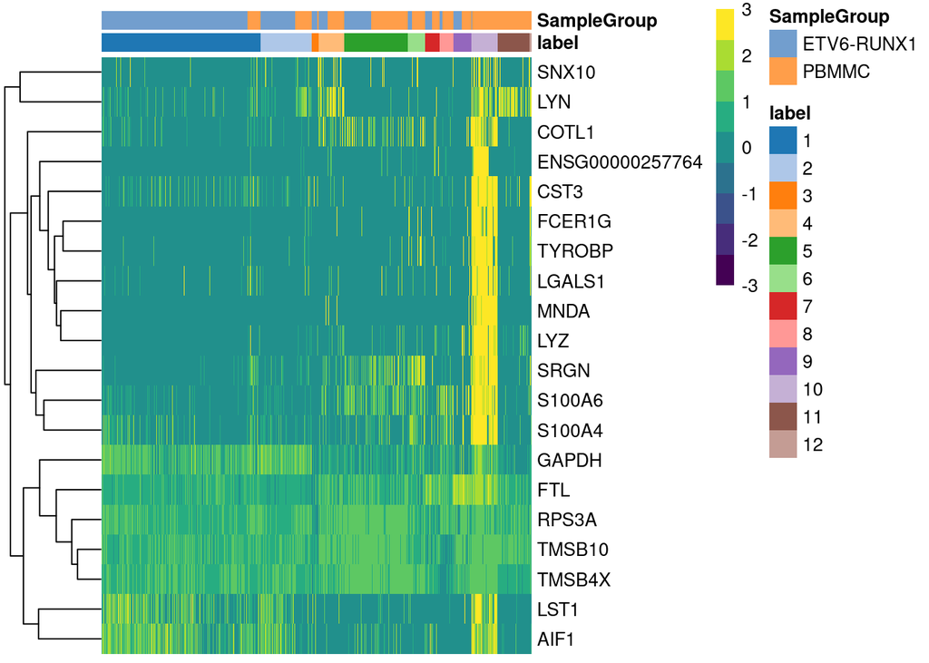

```r
plotHeatmap(sce,
            features = rownames(c10_top_genes),
            order_columns_by = c("label", "SampleGroup"),
                   scale = TRUE,
            zlim = c(-3, 3))
```

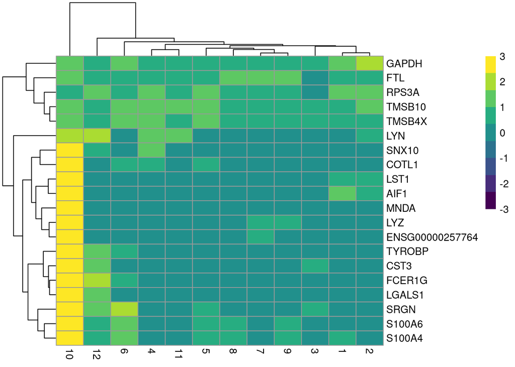

```r
plotGroupedHeatmap(sce,
                   features = rownames(c10_top_genes),
                   group = "label",
                   block = "SampleGroup",
                   scale = TRUE,
                   zlim = c(-3, 3))
```

In this case, the colour scale can be interpreted as the number of standard deviations above/below the mean of that gene across all cells.

## 3.3 Adjusting the log-fold change

The AUC and Cohen’s *d* scores incorporate both the gene expression differences between the clusters and the variance in gene expression scores within each cluster. If a gene has low variance, it is possible that it will be ranked highly even if the magnitude of the difference between the clusters is low. These genes will not necessarily make good marker genes. It may therefore be desirable to favour the detection of genes with larger log-fold changes. A log-fold change threshold can be set using the `lfc=` argument in score markers.

For example, in the results from cluster 12, the gene *FLT3* was one of twelve genes with a min-rank for Cohen’s *d* of <= 2:

```r
c12_top_markers <- markers[["12"]] %>%
  as.data.frame() %>%
  filter(rank.logFC.cohen <= 2)
c12_top_markers
```

```
##        self.average other.average self.detected other.detected mean.logFC.cohen
## BCL11A    2.5597632   0.673656529     1.0000000     0.43500060         4.295020
## BARD1     0.2689306   0.160150947     0.4098060     0.16325835         2.072739
## ITM2C     2.3944964   0.261977162     1.0000000     0.21510550         3.970727
## JCHAIN    3.6828986   0.147571599     0.9942291     0.12729264         4.643411
## RUNX2     1.9940529   0.027061353     0.9621311     0.04774555         4.011271
## IRF7      2.2625850  -0.005048526     1.0000000     0.10968092         3.724924
## FLT3      0.7501986   0.389592874     0.8358371     0.19755797         4.383935
## RNASE6    2.0619414   0.101283020     0.9581394     0.04106427        15.755818
## MYL12B    1.7985204   1.051154164     1.0000000     0.65839735         1.583985
## TCF4      3.8230779   1.098850268     1.0000000     0.51814747         5.824225
## APP       3.3179797   0.559174688     1.0000000     0.31835937         6.149314
## CSF2RA    1.0149433   0.067897536     0.7995278     0.04476525         4.403210
##        min.logFC.cohen median.logFC.cohen max.logFC.cohen rank.logFC.cohen
## BCL11A       1.1065147          3.1470728        9.465890                2
## BARD1       -0.9333552          0.6497261       13.830714                2
## ITM2C        2.1315731          3.5748377        6.236486                1
## JCHAIN       2.5834601          4.9212007        7.133094                2
## RUNX2        1.9091452          3.2871376        6.552932                1
## IRF7         2.5483824          3.7248230        4.358549                2
## FLT3        -0.1260248          3.4701584       13.830714                2
## RNASE6       1.5742114         14.1748874       42.479856                1
## MYL12B       0.2044665          0.9006073        8.758852                2
## TCF4         1.6567226          5.9027751        9.998347                2
## APP          3.6408789          4.9336464       11.793986                2
## CSF2RA       0.2511451          3.0948585       13.830714                1
##         mean.AUC   min.AUC median.AUC   max.AUC rank.AUC mean.logFC.detected
## BCL11A 0.9019988 0.7416813  0.9350649 0.9642857       13           1.4149321
## BARD1  0.6280138 0.2740506  0.6071429 1.0000000        1           0.5746046
## ITM2C  0.9663615 0.8392857  0.9801587 1.0000000        1           1.7100349
## JCHAIN 0.9674165 0.8896104  0.9732143 1.0000000        1           1.7058765
## RUNX2  0.9213730 0.8651489  0.9107143 0.9740260       21           1.7951997
## IRF7   0.9742683 0.9562172  0.9758491 1.0000000        1           1.9638433
## FLT3   0.7275427 0.4882883  0.7379913 1.0000000        1           1.2461015
## RNASE6 0.9578152 0.8623646  0.9649235 1.0000000        1           1.9874992
## MYL12B 0.7403881 0.5357143  0.7501887 1.0000000        1           0.8358841
## TCF4   0.9597523 0.8571429  0.9684764 1.0000000        1           1.2047328
## APP    0.9510964 0.8571429  0.9557762 0.9920635        3           1.6276777
## CSF2RA 0.8469413 0.5794224  0.8744541 1.0000000        1           1.8941064
##        min.logFC.detected median.logFC.detected max.logFC.detected
```

[output cut: 10 more lines]

```
## APP            0.67305151             1.6311527           2.496296
## CSF2RA         0.37483908             2.1138467           2.326343
##        rank.logFC.detected
## BCL11A                   2
## BARD1                    1
## ITM2C                   22
## JCHAIN                   5
## RUNX2                    9
## IRF7                     5
## FLT3                     1
## RNASE6                   1
## MYL12B                   1
## TCF4                     5
## APP                      2
## CSF2RA                   1
```

However, we can also see that its LFC goes from -0.1 to 13.8, which is a huge range!

```r
c12_top_markers["FLT3", ] %>%
  select(min.logFC.cohen, max.logFC.cohen)
```

```
##      min.logFC.cohen max.logFC.cohen
## FLT3      -0.1260248        13.83071
```

Looking at its expression, we can see what might be going on:

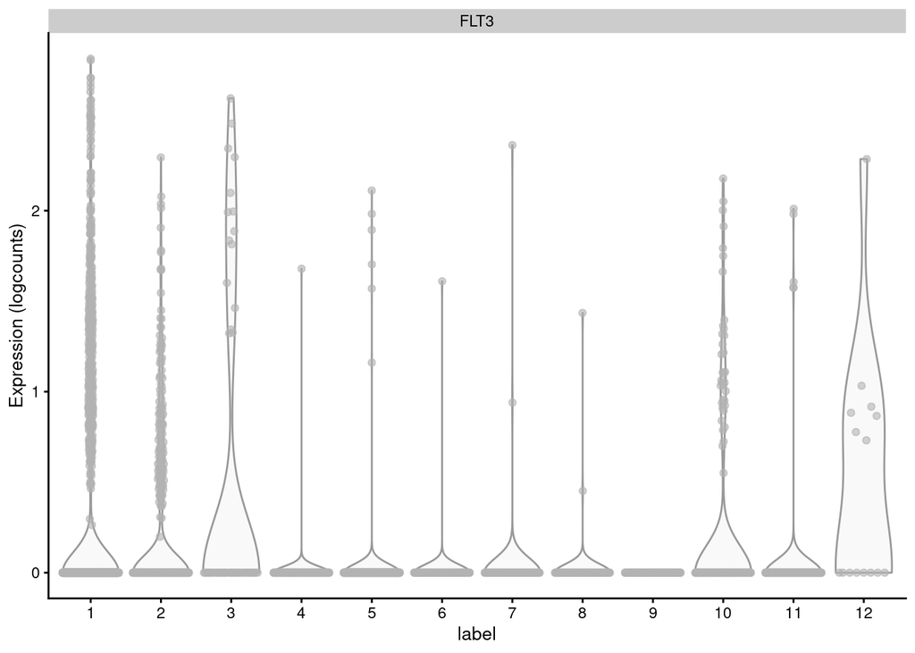

```r
plotExpression(sce,
               features = "FLT3",
               x = "label")
```

This gene has very low variation in expression in some clusters, and because Cohen’s *d* measures average differences *scaled by variance*, the gene comes up as having a high value for that metric in some comparisons.

To make our analysis more restrictive, we can instead indicate to the `scoreMarkers()` function what is the minimum LFC threshold we want to use to consider a gene for ranking. For example, a LFC > 2:

```r
markers_lfc <- scoreMarkers(sce,
                           groups = sce$label,
                           block = sce$SampleName,
                           lfc = 2)
```

FLT3 no longer appears in the candidate cluster marker genes list by min-rank of Cohen’s *d*.

```r
c12_markers_lfc <- as.data.frame(markers_lfc[["12"]])

c12_markers_lfc %>%
  select(contains("cohen")) %>%
  filter(rank.logFC.cohen <= 2)
```

```
##        mean.logFC.cohen min.logFC.cohen median.logFC.cohen max.logFC.cohen
## RPL31        -2.0770791      -4.8144787       -2.793087139        3.072737
## JCHAIN        1.9511846       0.5136757        2.149542943        3.348834
## PLAC8         1.1619955      -0.1321631        1.164217120        3.333530
## FHIP1A        0.5125335      -0.9692980       -0.006702181        3.639111
## FCHSD2        1.2318180      -0.4836114        1.347720886        3.601409
## TCF4          2.1504036      -0.6453323        2.398848237        4.639553
## RPS28        -1.9856597      -5.1160247       -2.552505189        3.983252
## APP           2.1427676       0.7898421        1.653588236        4.947973
##        rank.logFC.cohen
## RPL31                 2
## JCHAIN                1
## PLAC8                 1
## FHIP1A                1
## FCHSD2                2
## TCF4                  1
## RPS28                 1
## APP                   1
```

In fact it’s min-rank for Cohen’s *d* has dropped to:

```r
c12_markers_lfc["FLT3",  c("rank.logFC.cohen")]
```

```
## [1] 1623
```

From the OSCA book:

> Given that scoreMarkers() already reports effect sizes, it is tempting to take the next step and obtain p-values for the pairwise comparisons. Unfortunately, the p-values from the relevant tests cannot be reliably used to reject the null hypothesis. This is because DE analysis is performed on the same data used to obtain the clusters, which represents “data dredging” (also known as fishing or data snooping). The hypothesis of interest - are there differences between clusters? - is formulated from the data, so we are more likely to get a positive result when we re-use the data set to test that hypothesis.

The main thing to remember is that, in practice, this is a valid approach to help us annotate groups of cells based on the expression of genes with known cell-specificity and to find new interesting genes for further experiments and validation (e.g. using microscopy or qPCR). In other words, identifying cluster marker genes should be taken as a way to generate new hypothesis from our data, rather than a valid statistical model to test for differential expression between cell types.